# Question 4

```r
pacman::p_load(tidyverse, broom, modelr, GGally, olsrr, pander, stargazer)
```

```r
hertz_data <-
  read_csv(file.path(data_path, "cust_survey_transaction.csv")) %>%
  rename(`Total_charge_USD` = `Total _charge_USD`)
```

```r
hertz_data %>%
  select_if(function(x) any(is.na(x))) %>%
  summarise_all(funs(sum(is.na(.)))) %>%
  gather(Column, `Missing Values`) %>%
  pander(justify = c('left', 'right'))
```

| Column | Missing Values |
| --- | --- |
| Overall_Exper | 28,045 |
| Staff_Courtesy | 2,260 |
| Speed_of_Service | 2,264 |
| Veh_Equip_Condition | 2,265 |
| Trans_Billing_as_Expected | 2,281 |
| Value_for_the_Money | 2,283 |
| rent_loc_type | 2,289 |
| rent_loc_name | 20 |
| cust_tier_code | 251 |

We will not use the `Overall_Exper` column because 28,045 records have no response - 35% of the customer responses.

# A

We treat the survey questions continuous variables, though we know they are actually ordinal and discrete.

```r
base_formula <- as.formula(Recom_mend_Hertz ~ Staff_Courtesy +
                             Speed_of_Service + Trans_Billing_as_Expected +
                             Value_for_the_Money + Total_charge_USD +
                             Veh_Equip_Condition + Survey_checkout_diff)
lm1 <- lm(base_formula, data = hertz_data)
regression_results(lm1, title = "Full Model Results")
```

**Full Model Results**

|  | *Dependent variable:* |
| --- | --- |
|  | Recom_mend_Hertz |
| Constant | -0.576*** |
|  | p = 0.000 |
| Staff_Courtesy | 0.239*** |
|  | p = 0.000 |
| Speed_of_Service | 0.198*** |
|  | p = 0.000 |
| Trans_Billing_as_Expected | 0.161*** |
|  | p = 0.000 |
| Value_for_the_Money | 0.294*** |
|  | p = 0.000 |
| Total_charge_USD | 0.0001*** |
|  | p = 0.000 |
| Veh_Equip_Condition | 0.179*** |
|  | p = 0.000 |
| Survey_checkout_diff | -0.003** |
|  | p = 0.023 |
| Observations | 78,440 |
| R<sup>2</sup> | 0.671 |
| Adjusted R<sup>2</sup> | 0.671 |
| *Note:* | p<0.1; p<0.05; p<0.01 |

We see that increases in all survey questions and an increase in `Total_charge_USD` are associated with an increase in response to recommending Hertz. We note that `Survey_checkout_diff` is significant at the 95% but not the 99% confidence. For a more parsimonious model, we remove this variable.

## Multicolinearity

We would expect that many survey questions are correlated thus resulting in issues with multicolinearity. One measure of multicolinearity is *variance inflation factors* (VIF) - a measure of how much the variance of each regression coefficient $\beta_k$ is inflated by the existence of correlation among the predictor variables in the model[^1]. There are lots of “rules-of-thumb” about what qualifies as a VIF that is indicates multicollinearity. A VIF of 4 is often indicates a need to investigate and while that’s not the case here, can should still investigate further.

$$VIF = \frac{1}{1 - R^2_k}$$

```r
ols_vif_tol(lm1) %>% pander()
```

| Variables | Tolerance | VIF |
| --- | --- | --- |
| Staff_Courtesy | 0.4972 | 2.011 |
| Speed_of_Service | 0.5193 | 1.926 |
| Trans_Billing_as_Expected | 0.5803 | 1.723 |
| Value_for_the_Money | 0.4811 | 2.079 |
| Total_charge_USD | 0.9892 | 1.011 |
| Veh_Equip_Condition | 0.6633 | 1.508 |
| Survey_checkout_diff | 0.9949 | 1.005 |

We then look at a correlation plot of each of the variables (including `Overall_Exper`) in the model:

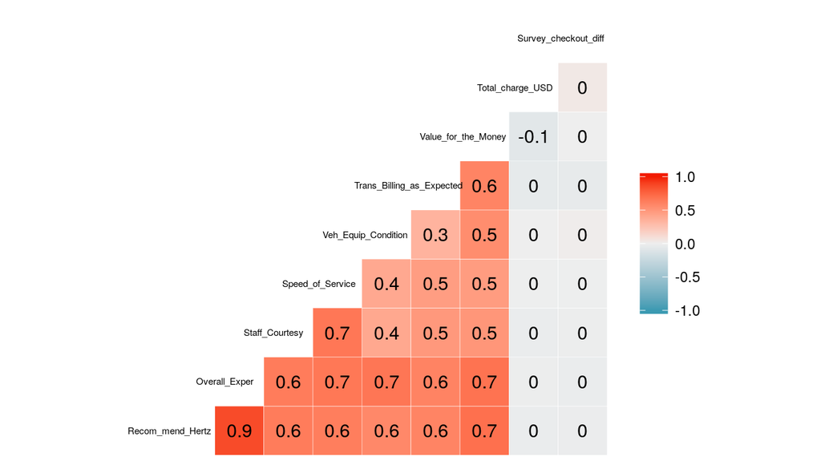

Figure 1: Pearson’s Correlation Coefficient between each variable in model

```r
hertz_data %>%
  select(Recom_mend_Hertz, Overall_Exper, Staff_Courtesy, Speed_of_Service,
         Veh_Equip_Condition, Trans_Billing_as_Expected,  Value_for_the_Money,
         Total_charge_USD, Survey_checkout_diff) %>%
  ggcorr(label = TRUE, size = 2, hjust = 0.75, layout.exp = 1)
```

We then perform step-wise backwards elimination (using $p$-values) to remove variables from the model:

```r
lm2 <- update(lm1, . ~ . - Survey_checkout_diff)
regression_results(lm1, lm2, title = "Model Comparison")
```

**Model Comparison**

|  | *Dependent variable:* |  |
| --- | --- | --- |
|  | Recom_mend_Hertz |  |
|  | (1) | (2) |
| Constant | -0.576*** | -0.587*** |
|  | p = 0.000 | p = 0.000 |
| Staff_Courtesy | 0.239*** | 0.239*** |
|  | p = 0.000 | p = 0.000 |
| Speed_of_Service | 0.198*** | 0.198*** |
|  | p = 0.000 | p = 0.000 |
| Trans_Billing_as_Expected | 0.161*** | 0.161*** |
|  | p = 0.000 | p = 0.000 |
| Value_for_the_Money | 0.294*** | 0.294*** |
|  | p = 0.000 | p = 0.000 |
| Total_charge_USD | 0.0001*** | 0.0001*** |
|  | p = 0.000 | p = 0.000 |
| Veh_Equip_Condition | 0.179*** | 0.179*** |
|  | p = 0.000 | p = 0.000 |
| Survey_checkout_diff | -0.003** |  |
|  | p = 0.023 |  |
| Observations | 78,440 | 78,440 |
| R<sup>2</sup> | 0.671 | 0.671 |
| Adjusted R<sup>2</sup> | 0.671 | 0.671 |
| *Note:* | p<0.1; p<0.05; p<0.01 |  |

## Results

Variable importance is indicated by the value of each coefficient’s test statistic. So we sort the coefficient estimates on the test statistic.

For each of the survey questions below, we can say that a one-unit increase in the variable is associated with a $\beta_k$ increase in response to the question about recommending Hertz. For example, a one-unit increase in reponse to the question on `Value_for_the_Money` is associated with a 0.29 increase in the question to about recommending Hertz.

```r
tidy(lm2) %>%
  as_tibble() %>%
  filter(term != "(Intercept)") %>%
  arrange(desc(statistic)) %>%
  select(term, statistic, estimate) %>%
  pander(justify = c('left', 'right', 'right'))
```

| term | statistic | estimate |
| --- | --- | --- |
| Value_for_the_Money | 100.9 | 0.2943 |
| Veh_Equip_Condition | 77.86 | 0.1788 |
| Speed_of_Service | 72.9 | 0.1977 |
| Staff_Courtesy | 65.5 | 0.2395 |
| Trans_Billing_as_Expected | 61.82 | 0.161 |
| Total_charge_USD | 8.03 | 0.0001355 |

# B

To test if the relationships change by Rental Location Type, Rental Purpose, and Booking Channel, we individual add each to the base model. The results are shown in the table below:

```r
lm3 <- update(lm2, . ~ . + rent_loc_type)
lm4 <- update(lm2, . ~ . + Purpose_of_Rental)
lm5 <- update(lm2, . ~ . + as.factor(booking_channel_dummy))
regression_results(lm2, lm3, lm4, lm5,
                   title = "Rental Location Type, Rental Purpose, and Booking Channel")
```

**Rental Location Type, Rental Purpose, and Booking Channel**

|  | *Dependent variable:* |  |  |  |
| --- | --- | --- | --- | --- |
|  | Recom_mend_Hertz |  |  |  |
|  | (1) | (2) | (3) | (4) |
| Constant | -0.587*** | -0.584*** | -0.608*** | -0.635*** |
|  | p = 0.000 | p = 0.000 | p = 0.000 | p = 0.000 |
| Staff_Courtesy | 0.239*** | 0.241*** | 0.239*** | 0.239*** |
|  | p = 0.000 | p = 0.000 | p = 0.000 | p = 0.000 |
| Speed_of_Service | 0.198*** | 0.198*** | 0.198*** | 0.198*** |
|  | p = 0.000 | p = 0.000 | p = 0.000 | p = 0.000 |
| Trans_Billing_as_Expected | 0.161*** | 0.161*** | 0.162*** | 0.161*** |
|  | p = 0.000 | p = 0.000 | p = 0.000 | p = 0.000 |
| Value_for_the_Money | 0.294*** | 0.294*** | 0.293*** | 0.294*** |
|  | p = 0.000 | p = 0.000 | p = 0.000 | p = 0.000 |
| Total_charge_USD | 0.0001*** | 0.0001*** | 0.0001*** | 0.0001*** |
|  | p = 0.000 | p = 0.000 | p = 0.000 | p = 0.000 |
| Veh_Equip_Condition | 0.179*** | 0.179*** | 0.179*** | 0.179*** |
|  | p = 0.000 | p = 0.000 | p = 0.000 | p = 0.000 |
| rent_loc_typeOFF AP |  | -0.023*** |  |  |
|  |  | p = 0.009 |  |  |
| Purpose_of_RentalIns. Rep. or Loaner |  |  | 0.114** |  |
|  |  |  | p = 0.042 |  |
| Purpose_of_RentalLeis. / Pers. |  |  | 0.059*** |  |
|  |  |  | p = 0.000 |  |
| as.factor(booking_channel_dummy)1 |  |  |  | 0.104*** |
|  |  |  |  | p = 0.000 |
| Observations | 78,440 | 76,157 | 78,440 | 78,440 |
| R<sup>2</sup> | 0.671 | 0.671 | 0.671 | 0.671 |
| Adjusted R<sup>2</sup> | 0.671 | 0.671 | 0.671 | 0.671 |
| *Note:* | p<0.1; p<0.05; p<0.01 |  |  |  |

1. **Rental Location Type**: Yes - all survey question responses held constant, picking up the rental car at the airport increases the response about recommending Hertz by 0.023 points. In reality, this would not translate into a full point.
2. **Rental Purpose**: Yes - all survey question responses held constant, the renting for Rep. Insur. or Loaner compared to Bus. is associated with a 0.114 increase in recommending Hertz and Leis. / Pers. compared to Bus. is assoicated with a 0.059 increase in recommending Hertz.
3. **Booking Channel**: Yes - all survey question responses held constant, booking through hertz.com increases the response about recommending Hertz by 0.104 points. In reality, this would not translate into a full point.

# C

Useful features to segment customers on need to meet the following criteria:

1. intrinsic to the customer or the customer’s experience with Hertz
2. contain variation (i.e `rent_corp_lic` is split 95% and 5%)
3. not contain too many levels (i.e. segmenting on all US/CN states would not be helpful)

We will explore a few in this dataset:

## Customer Tier

The customer tier is the status in the loyalty program the customer is in. We look at the mean response to recommend Hertz within each tier:

```r
hertz_data %>%
  group_by(cust_tier_code) %>%
  summarise(n = n(), mean = mean(Recom_mend_Hertz, na.rm = TRUE)) %>%
  arrange(desc(n)) %>%
  pander()
```

| cust_tier_code | n | mean |
| --- | --- | --- |
| RG | 46,647 | 7.572 |
| FG | 15,763 | 7.679 |
| N1 | 11,390 | 7.553 |
| PC | 5,958 | 7.934 |
| PL | 703 | 8.28 |
| NA | 251 | 7.394 |
| VP | 8 | 8.125 |
| PS | 3 | 8.667 |

We add this variable to the model and use `anova` to test if the added variable contributes to the predictive ability of the model. We see that customer tier would improve our base model.

```r
lm6 <- update(lm2, . ~ . + cust_tier_code)
anova(lm6, lm(lm2$call, data = lm6$model)) %>%
  pander(missing = "")
```

Analysis of Variance Table

| Res.Df | RSS | Df | Sum of Sq | F | Pr(>F) |
| --- | --- | --- | --- | --- | --- |
| 78,189 | 114,553 |  |  |  |  |
| 78,195 | 114,683 | -6 | -129.5 | 14.73 | 6.795e-17 |

## Country

There are 75 countries in the dataset - segmenting on country by itself would not be useful. We try instead an is_US indicator:

```r
hertz_data %>%
  mutate(is_US = if_else(addr_country == "US", addr_country, "non-US")) %>%
  group_by(is_US) %>%
  summarise(n = n(), mean = mean(Recom_mend_Hertz, na.rm = TRUE)) %>%
  pander()
```

| is_US | n | mean |
| --- | --- | --- |
| non-US | 3,472 | 7.582 |
| US | 77,251 | 7.625 |

The results below demonstrates that this indicator of US and non-US would not be useful.

```r
lm7 <- lm(update(lm2$call$formula, ~. + is_US), data = hertz_data %>%
             mutate(is_US = if_else(addr_country == "US", addr_country, "non-US")))
anova(lm7, lm2) %>%
  pander(missing = "")
```

Analysis of Variance Table

| Res.Df | RSS | Df | Sum of Sq | F | Pr(>F) |
| --- | --- | --- | --- | --- | --- |
| 78,432 | 115,156 |  |  |  |  |
| 78,433 | 115,158 | -1 | -1.753 | 1.194 | 0.2746 |

## Rental Day

We check to see if the day the vehicle was rented affects likelihood to recommend, hypothesizing that weekend rentals might be more likeluy to recommend. We see that this is not the case.

```r
hertz_data %>%
  select(Recom_mend_Hertz,  rent_day) %>%
  group_by(rent_day) %>%
  summarise(n = n(), mean = mean(Recom_mend_Hertz, na.rm = TRUE)) %>%
  arrange(rent_day) %>%
  pander()
```

| rent_day | n | mean |
| --- | --- | --- |
| 1 | 7,021 | 7.486 |
| 2 | 15,967 | 7.572 |
| 3 | 12,630 | 7.58 |
| 4 | 11,234 | 7.587 |
| 5 | 11,683 | 7.714 |
| 6 | 13,755 | 7.735 |
| 7 | 8,433 | 7.636 |

```r
lm8 <- update(lm2, . ~ . + rent_day)
anova(lm8, lm(lm2$call, data = lm8$model)) %>%
  pander(missing = "")
```

Analysis of Variance Table

| Res.Df | RSS | Df | Sum of Sq | F | Pr(>F) |
| --- | --- | --- | --- | --- | --- |
| 78,432 | 115,155 |  |  |  |  |
| 78,433 | 115,158 | -1 | -2.079 | 1.416 | 0.2341 |

## Difference in Car Reserved and Car Given

Finally, we hypothesize that if customers were given a differnet car than they reserved, this may affect their likelihood to recommend (either in a positive or negative way). However, we do not find that a segmentation on this dimension would be valuable.

```r
hertz_data %>%
  mutate(is_same = if_else(xgra_veh_class == xgra_vclass_reserv, "Same", "Different")) %>%
  group_by(is_same) %>%
  summarise(n = n(), mean = mean(Recom_mend_Hertz, na.rm = TRUE)) %>%
  pander()
```

| is_same | n | mean |
| --- | --- | --- |
| Different | 61,135 | 7.642 |
| Same | 19,588 | 7.563 |

```r
lm9 <- lm(update(lm2$call$formula, ~. + is_same), data = hertz_data %>%
             mutate(is_same = if_else(xgra_veh_class == xgra_vclass_reserv, "Same", "Different")))
anova(lm9, lm2) %>%
  pander(missing = "")
```

Analysis of Variance Table

| Res.Df | RSS | Df | Sum of Sq | F | Pr(>F) |
| --- | --- | --- | --- | --- | --- |
| 78,432 | 115,156 |  |  |  |  |
| 78,433 | 115,158 | -1 | -1.242 | 0.8459 | 0.3577 |

## D

1. The segmentation exercise only involved customers who had completed a survey. The respondents likely have a more positive view of Hertz than the typical customer. Rather than segment based on someone’s response “how likely are you to recommend”, Hertz could track the referrals people make to others as this represents behavior rather than perceived intent.
2. We are segmenting customers based on their responses to other survey questions. This bias does not really help make this segmentation actionable as it’s merely descriptive. This analysis only helps tell us that “value for money” is driver in someone’s propensity to recommend, but it does not enable future targeting. Segmentation based only on customer characteristics (i.e. age, location, income, vehicle use-case) is much more actionable.
3. We treated an ordinal discrete variables (survey responses on a 1-9 scale) as a continuous variable. We could have performed the analysis using parametric tests that are more suitable to likert scale data.
[^1]: https://cran.r-project.org/web/packages/olsrr/vignettes/regression_diagnostics.html